# ToothGrowth Dataset Analysis

Gabe Rudy

April 20, 2015

The response is the length of odontoblasts (teeth) in each of 10 guinea pigs at each of three dose levels of Vitamin C (0.5, 1, and 2 mg) with each of two delivery methods (orange juice or ascorbic acid).

```r
library(datasets)
summary(ToothGrowth$len)
```

```
##    Min. 1st Qu.  Median    Mean 3rd Qu.    Max.
##    4.20   13.08   19.25   18.81   25.28   33.90
```

```r
#Create a list by supplement type
by_supp <- split(ToothGrowth$len, ToothGrowth$supp)
summary(by_supp$OJ)
summary(by_supp$VC)
```

```
##    Min. 1st Qu.  Median    Mean 3rd Qu.    Max.
##    8.20   15.52   22.70   20.66   25.72   30.90
##    Min. 1st Qu.  Median    Mean 3rd Qu.    Max.
##    4.20   11.20   16.50   16.96   23.10   33.90
```

```r
#Create a list by dosage levels
by_dose <- split(ToothGrowth$len, ToothGrowth$dose)
summary(by_dose$`0.5`)
summary(by_dose$`1`)
summary(by_dose$`2`)
```

```
##    Min. 1st Qu.  Median    Mean 3rd Qu.    Max.
##   4.200   7.225   9.850  10.600  12.250  21.500
##    Min. 1st Qu.  Median    Mean 3rd Qu.    Max.
##   13.60   16.25   19.25   19.74   23.38   27.30
##    Min. 1st Qu.  Median    Mean 3rd Qu.    Max.
##   18.50   23.52   25.95   26.10   27.83   33.90
```

We can see by the summary information that that *OJ* has a greater mean than *VC* (absorbic acid) delivery. Also, the mean length increases with dosage.

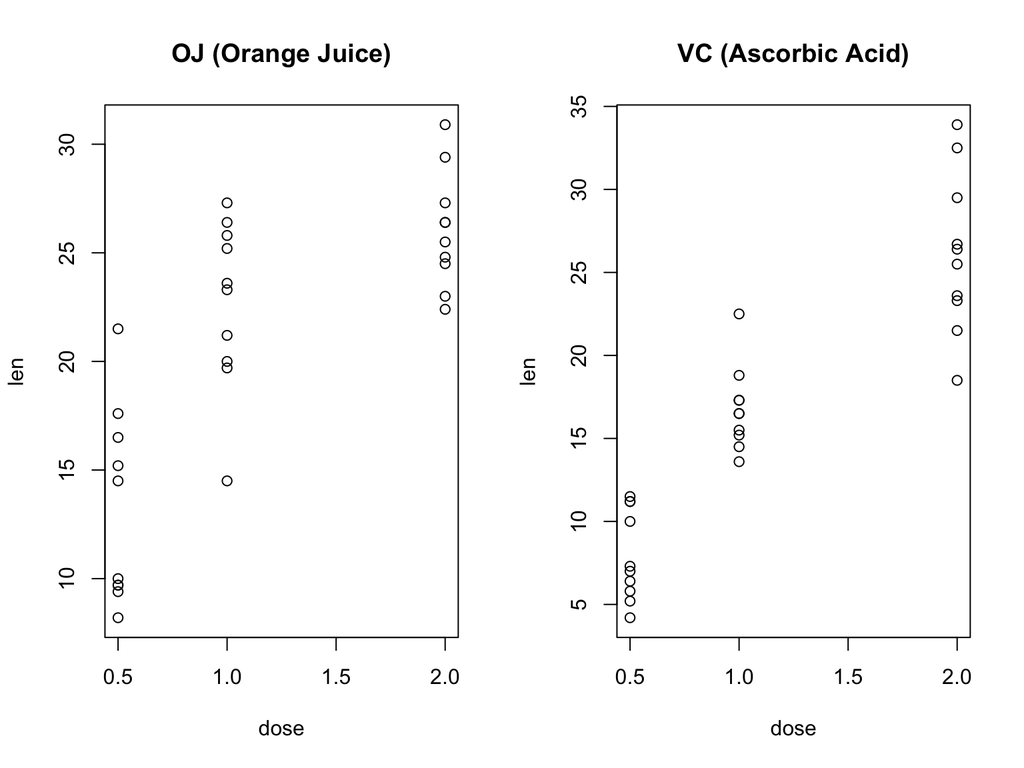

## Confidence Interval and Tests for Supplement Type

Lets compare the observations in group OJ and VC.

We will use a Student’s t-Test to compare the two groups with `0.95` confidence level.

```r
t.test(by_supp$OJ, by_supp$VC, paired=FALSE, var.equal = TRUE)
```

```
##
##  Two Sample t-test
##
## data:  by_supp$OJ and by_supp$VC
## t = 1.9153, df = 58, p-value = 0.06039
## alternative hypothesis: true difference in means is not equal to 0
## 95 percent confidence interval:
##  -0.1670064  7.5670064
## sample estimates:
## mean of x mean of y
##  20.66333  16.96333
```

Our T test statistic is `1.9`, meaning we estimate our difference of means is `1.9` standard error from the hypothosized mean. The P-value is `0.06`, meaning there is `0.06` probability of obtaining differences of means greather than the observed if the truely where no difference based on supplement type.

We are makeing the assumption that *the variance of the two groups is equal*. We are also making a two-sided test, saying the difference of the means could be either greater than or less than, not just strictly greater than or less than.

## Confidence Interval and Tests for Dose

Lets compare the observations in dosage group `0.5` and `2`.

We will use a Student’s t-Test to compare the two groups with a `0.95` confidence level.

```r
t.test(by_dose$`0.5`, by_dose$`2`, paired=FALSE, var.equal = TRUE)
```

```
##
##  Two Sample t-test
##
## data:  by_dose$`0.5` and by_dose$`2`
## t = -11.799, df = 38, p-value = 2.838e-14
## alternative hypothesis: true difference in means is not equal to 0
## 95 percent confidence interval:
##  -18.15352 -12.83648
## sample estimates:
## mean of x mean of y
##    10.605    26.100
```